# Python Assignment

## German Credit Scoring Case

### Looking at the data

```
#Import and read data
```

```
import pandas as pd
```

```
credit = pd.read_csv("creditgb2.csv")
```

```
credit.head(5)
```

|  | creditability | balance_credit_acc | balance_credit_acc.1 | duration | moral | credit_purpose | credit_in _use | savings_or_stocks | years_curr_employer | rate | ... | curr_hhld_tenure | assets | age | further_credits | apartment_type | prev_credits_here | occupation | economic_dependants | telephone | foreign_worker |
| --- | --- | --- | --- | --- | --- | --- | --- | --- | --- | --- | --- | --- | --- | --- | --- | --- | --- | --- | --- | --- | --- |
| 0 | 1 | 1 | 1 | 18 | 4 | 2 | 1049 | N | 2 | 4 | ... | 9 | 2 | 21 | 3 | 1 | 1 | 3 | 1 | 1 | 1 |
| 1 | 1 | 1 | 1 | 9 | 4 | 0 | 2799 | N | 3 | 2 | ... | 3 | 1 | 36 | 3 | 1 | 2 | 3 | 2 | 1 | 1 |
| 2 | 1 | 2 | 2 | 12 | 2 | 9 | 841 | 40 | 4 | 2 | ... | 20 | 1 | 23 | 3 | 1 | 1 | 2 | 1 | 1 | 1 |
| 3 | 1 | 1 | 1 | 12 | 4 | 0 | 2122 | N | 3 | 3 | ... | 3 | 1 | 39 | 3 | 1 | 2 | 2 | 2 | 1 | 2 |
| 4 | 1 | 1 | 1 | 12 | 4 | 0 | 2171 | N | 3 | 4 | ... | 9 | 2 | 38 | 1 | 2 | 2 | 2 | 1 | 1 | 2 |

5 rows × 22 columns

We immediately can see that the data has redundant columns (balance_credit_acc) as well as non-numeric values in the savings_or_stocks column. The data will have to be cleaned.

```
#Familiarize with the column names and check for redundant columns
```

```
col_names = credit.columns.tolist()
```

```
print "Column names:"
```

```
print col_names
```

```
Column names:
['creditability', 'balance_credit_acc', 'balance_credit_acc.1', 'duration', 'moral', 'credit_purpose', 'credit_in _use', 'savings_or_stocks', 'years_curr_employer', 'rate', 'status_sex', 'debtors_guarantors', 'curr_hhld_tenure', 'assets', 'age', 'further_credits', 'apartment_type', 'prev_credits_her…
```

There appears to only be one instance of redundant columns. The following code will remove balance_credit_acc.1.

```
credit=credit.drop(['balance_credit_acc.1'], axis=1)
```

```
#Renaming a column to remove space in order to use effectively in future code
```

```
credit.rename(columns={'credit_in _use':'credit_in_use'}, inplace=True)
```

Next we need to check if there are missing values. We do this by comparing the number of entries for each variable.

```
credit.info()
```

```
<class 'pandas.core.frame.DataFrame'>
Int64Index: 1009 entries, 0 to 1008
Data columns (total 21 columns):
creditability          1009 non-null int64
balance_credit_acc     1004 non-null float64
duration               1009 non-null int64
moral                  1009 non-null int64
credit_purpose         1009 non-null int64
credit_in_use          1003 non-null float64
savings_or_stocks      1005 non-null object
years_curr_employer    1009 non-null int64
rate                   1009 non-null int64
status_sex             1009 non-null int64
debtors_guarantors     1009 non-null int64
curr_hhld_tenure       1009 non-null int64
assets                 1009 non-null int64
age                    1005 non-null float64
further_credits        1009 non-null int64
apartment_type         1009 non-null int64
prev_credits_here      1009 non-null int64
occupation             1009 non-null int64
economic_dependants    1009 non-null int64
telephone              1009 non-null int64
foreign_worker         1009 non-null int64
dtypes: float64(3), int64(17), object(1)
```

We can see that there isn't an equal amount of entries for each variable indicating that some variables have values missing.

```
#Confirm total number of observations
```

```
len(credit)
```

```
1009
```

```
#Confirm total number of variables
```

```
len(credit.columns)
```

```
21
```

### Cleaning the Data

#### Missing Values

As we've seen, some of the variables above have missing data, but since the number of obserations containing missing data is less than 1%, we will simply drop those observations from the dataset

```
pd.isnull(credit.tail(5))
```

|  | creditability | balance_credit_acc | duration | moral | credit_purpose | credit_in_use | savings_or_stocks | years_curr_employer | rate | status_sex | ... | curr_hhld_tenure | assets | age | further_credits | apartment_type | prev_credits_here | occupation | economic_dependants | telephone | foreign_worker |
| --- | --- | --- | --- | --- | --- | --- | --- | --- | --- | --- | --- | --- | --- | --- | --- | --- | --- | --- | --- | --- | --- |
| 1004 | False | False | False | False | False | True | False | False | False | False | ... | False | False | True | False | False | False | False | False | False | False |
| 1005 | False | False | False | False | False | False | True | False | False | False | ... | False | False | False | False | False | False | False | False | False | False |
| 1006 | False | True | False | False | False | True | False | False | False | False | ... | False | False | True | False | False | False | False | False | False | False |
| 1007 | False | True | False | False | False | True | False | False | False | False | ... | False | False | False | False | False | False | False | False | False | False |
| 1008 | False | False | False | False | False | False | True | False | False | False | ... | False | False | False | False | False | False | False | False | False | False |

5 rows × 21 columns

```
credit1=credit.dropna()
```

```
len(credit1)
```

```
999
```

```
len(credit)-len(credit1)
```

```
10
```

A total of 10 rows/observations were droppped due to missing variables

#### Substitution of string values into numeric values

Since it is noticeable that an "N" character exists in some columns, we can infer that the client does not have the value for their customer. As such, we will substitute it by 0 for descriptive statistics purposes.

```
credit2 = credit1.replace("N",0)
```

```
#Confirm change of variable
```

```
credit2.head(5)
```

|  | creditability | balance_credit_acc | duration | moral | credit_purpose | credit_in_use | savings_or_stocks | years_curr_employer | rate | status_sex | ... | curr_hhld_tenure | assets | age | further_credits | apartment_type | prev_credits_here | occupation | economic_dependants | telephone | foreign_worker |
| --- | --- | --- | --- | --- | --- | --- | --- | --- | --- | --- | --- | --- | --- | --- | --- | --- | --- | --- | --- | --- | --- |
| 0 | 1 | 1 | 18 | 4 | 2 | 1049 | 0 | 2 | 4 | 2 | ... | 9 | 2 | 21 | 3 | 1 | 1 | 3 | 1 | 1 | 1 |
| 1 | 1 | 1 | 9 | 4 | 0 | 2799 | 0 | 3 | 2 | 3 | ... | 3 | 1 | 36 | 3 | 1 | 2 | 3 | 2 | 1 | 1 |
| 2 | 1 | 2 | 12 | 2 | 9 | 841 | 40 | 4 | 2 | 2 | ... | 20 | 1 | 23 | 3 | 1 | 1 | 2 | 1 | 1 | 1 |
| 3 | 1 | 1 | 12 | 4 | 0 | 2122 | 0 | 3 | 3 | 3 | ... | 3 | 1 | 39 | 3 | 1 | 2 | 2 | 2 | 1 | 2 |
| 4 | 1 | 1 | 12 | 4 | 0 | 2171 | 0 | 3 | 4 | 3 | ... | 9 | 2 | 38 | 1 | 2 | 2 | 2 | 1 | 1 | 2 |

5 rows × 21 columns

```
#Ensure all values are numeric in order to do calculations
```

```
credit2= credit2.convert_objects(convert_numeric='force')
```

```
#Check to ensure that all variables have the same number of observations and that all types are numeric
```

```
credit2.info()
```

```
<class 'pandas.core.frame.DataFrame'>
Int64Index: 999 entries, 0 to 998
Data columns (total 21 columns):
creditability          999 non-null int64
balance_credit_acc     999 non-null float64
duration               999 non-null int64
moral                  999 non-null int64
credit_purpose         999 non-null int64
credit_in_use          999 non-null float64
savings_or_stocks      999 non-null int64
years_curr_employer    999 non-null int64
rate                   999 non-null int64
status_sex             999 non-null int64
debtors_guarantors     999 non-null int64
curr_hhld_tenure       999 non-null int64
assets                 999 non-null int64
age                    999 non-null float64
further_credits        999 non-null int64
apartment_type         999 non-null int64
prev_credits_here      999 non-null int64
occupation             999 non-null int64
economic_dependants    999 non-null int64
telephone              999 non-null int64
foreign_worker         999 non-null int64
dtypes: float64(3), int64(18)
```

### Data Exploration

#### General Descriptive Statistics of all the variables

```
import numpy as np
```

```
import matplotlib as plt
```

```
credit2.describe()
```

|  | creditability | balance_credit_acc | duration | moral | credit_purpose | credit_in_use | savings_or_stocks | years_curr_employer | rate | status_sex | ... | curr_hhld_tenure | assets | age | further_credits | apartment_type | prev_credits_here | occupation | economic_dependants | telephone | foreign_worker |
| --- | --- | --- | --- | --- | --- | --- | --- | --- | --- | --- | --- | --- | --- | --- | --- | --- | --- | --- | --- | --- | --- |
| count | 999.000000 | 999.000000 | 999.000000 | 999.000000 | 999.000000 | 999.000000 | 999.000000 | 999.000000 | 999.000000 | 999.000000 | ... | 999.000000 | 999.000000 | 999.000000 | 999.000000 | 999.000000 | 999.000000 | 999.000000 | 999.000000 | 999.000000 | 999.000000 |
| mean | 0.700701 | 2.578579 | 20.893894 | 2.545546 | 2.828829 | 3268.166166 | 493.387387 | 3.382382 | 2.971972 | 2.681682 | ... | 9.370370 | 2.358358 | 35.546547 | 2.674675 | 1.927928 | 1.407407 | 2.903904 | 1.155155 | 1.404404 | 1.037037 |
| std | 0.458180 | 1.257276 | 12.061414 | 1.083525 | 2.745689 | 2822.481918 | 892.005039 | 1.207828 | 1.118802 | 0.708363 | ... | 8.753182 | 1.050674 | 11.357446 | 0.705879 | 0.530447 | 0.577800 | 0.653934 | 0.362234 | 0.491022 | 0.188947 |
| min | 0.000000 | 1.000000 | 4.000000 | 0.000000 | 0.000000 | 250.000000 | 0.000000 | 1.000000 | 1.000000 | 1.000000 | ... | 1.000000 | 1.000000 | 19.000000 | 1.000000 | 1.000000 | 1.000000 | 1.000000 | 1.000000 | 1.000000 | 1.000000 |
| 25% | 0.000000 | 1.000000 | 12.000000 | 2.000000 | 1.000000 | 1365.000000 | 0.000000 | 3.000000 | 2.000000 | 2.000000 | ... | 3.000000 | 1.000000 | 27.000000 | 3.000000 | 2.000000 | 1.000000 | 3.000000 | 1.000000 | 1.000000 | 1.000000 |
| 50% | 1.000000 | 2.000000 | 18.000000 | 2.000000 | 2.000000 | 2319.000000 | 0.000000 | 3.000000 | 3.000000 | 3.000000 | ... | 5.000000 | 2.000000 | 33.000000 | 3.000000 | 2.000000 | 1.000000 | 3.000000 | 1.000000 | 1.000000 | 1.000000 |
| 75% | 1.000000 | 4.000000 | 24.000000 | 4.000000 | 3.000000 | 3969.000000 | 393.000000 | 5.000000 | 4.000000 | 3.000000 | ... | 16.000000 | 3.000000 | 42.000000 | 3.000000 | 2.000000 | 2.000000 | 3.000000 | 1.000000 | 2.000000 | 1.000000 |
| max | 1.000000 | 4.000000 | 72.000000 | 4.000000 | 10.000000 | 18424.000000 | 2985.000000 | 5.000000 | 4.000000 | 4.000000 | ... | 30.000000 | 4.000000 | 75.000000 | 3.000000 | 3.000000 | 4.000000 | 4.000000 | 2.000000 | 2.000000 | 2.000000 |

8 rows × 21 columns

#### Summarizing Continuous Variables Grouped by Creditability

```
#Splitting and summarizing the continuous variables by creditability i.e. goods and bads
```

```
contvar = pd.DataFrame(data = credit2, columns = ['creditability','age', 'credit_in_use', 'curr_hhld_tenure', 'duration', 'prev_credits_here', 'rate', 'savings_or_stocks'])
```

```
creditgrouping = contvar.groupby('creditability').describe()
```

```
print creditgrouping
```

```
                            age  credit_in_use  curr_hhld_tenure    duration  \
creditability
0             count  299.000000     299.000000        299.000000  299.000000
              mean    33.969900    3930.060201          9.354515   24.842809
              std     11.242705    3538.980487          8.804823   13.301563
              min     19.000000     433.000000          1.000000    6.000000
              25%     25.000000    1350.000000          3.000000   12.000000
              50%     31.000000    2570.000000          5.000000   24.000000
              75%     40.000000    5112.500000         16.000000   36.000000
              max     74.000000   18424.000000         30.000000   72.000000
1             count  700.000000     700.000000        700.000000  700.000000
              mean    36.220000    2985.442857          9.377143   19.207143
              std     11.347428    2401.495579          8.737340   11.079564
              min     19.000000     250.000000          1.000000    4.000000
              25%     27.000000    1375.500000          3.000000   12.000000
              50%     34.000000    2244.000000          5.000000   18.000000
              75%     42.000000    3634.750000         16.000000   24.000000
              max     75.000000   15857.000000         30.000000   60.000000

                     prev_credits_here        rate  savings_or_stocks
creditability
0             count         299.000000  299.000000         299.000000
              mean            1.367893    3.093645         276.294314
              std             0.560237    1.088959         723.804574
              min             1.000000    1.000000           0.000000
              25%             1.000000    2.000000           0.000000
              50%             1.000000    4.000000           0.000000
              75%             2.000000    4.000000          27.000000
              max             4.000000    4.000000        2984.000000
1             count         700.000000  700.000000         700.000000
              mean            1.424286    2.920000         586.117143
              std             0.584721    1.128078         940.163026
              min             1.000000    1.000000           0.000000
              25%             1.000000    2.000000           0.000000
              50%             1.000000    3.000000           0.000000
              75%             2.000000    4.000000        1246.000000
              max             4.000000    4.000000        2985.000000
```

Based on the results, we can see that there are some difference in the mean that arise in a few key variables.

*Average Age for Bads is lower than Goods

*Average Credit in Use is higher for Bads

*Average duration is longer for Bads than for Goods

*Average Savings of bad accounts is lower by more than 50% as compared to good accounts

#### Plotting and Charting

```
import matplotlib.pyplot as plt
```

```
%matplotlib inline
```

```
import numpy as np
```

```
from pylab import *
```

```
#axes=figure().add_subplot(111)
```

```
#a=axes.get_xticks().tolist()
```

```
#a= ["No Running Account", "No Balance or Debt", "0<=...<200", "...>200 DM"]
```

```
import matplotlib.pyplot as plt
```

```
%matplotlib inline
```

```
import numpy as np
```

```
credit2.balance_credit_acc.hist(bins=10, range=(1,4))
```

```
plt.title('Histogram of Credit Balance')
```

```
plt.xlabel('Credit Balance')
```

```
plt.ylabel('Frequency')
```

```
#axes.set_xticklabels(a, rotation=45 ,ha='left')
```

```
plt.tick_params(axis = 'x', which='both', labelbottom='off')
```

```
savefig('creditbalacebar.png')
```

```
from pylab import savefig
```

```
savefig('histcreditbalance.png')
```

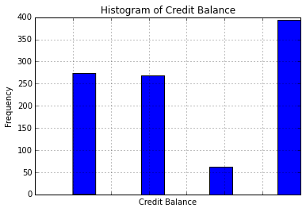

```
#Histogram of Age
```

```
import matplotlib as plt1
```

```
fig = plt1.pyplot.figure()
```

```
ax = fig.add_subplot(111)
```

```
ax.hist(credit2['age'], bins = 10, range = (credit2['age'].min(),credit2['age'].max()))
```

```
plt1.pyplot.title('Age distribution')
```

```
plt1.pyplot.xlabel('Age')
```

```
plt1.pyplot.ylabel('Customer count')
```

```
plt1.pyplot.show()#credit2.age.hist(bins=10, range = (credit2['age'].min(),credit2['age'].max()))
```

```
savefig('agedist.png')
```

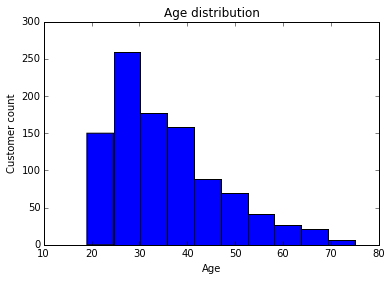

```
#Histogram of Credit in Use
```

```
fig = plt1.pyplot.figure()
```

```
ax = fig.add_subplot(111)
```

```
ax.hist(credit2['credit_in_use'], bins = 11, range = (credit2['credit_in_use'].min(),credit2['credit_in_use'].max()))
```

```
plt1.pyplot.title('Credit in Use')
```

```
plt1.pyplot.xlabel('Credit in Use')
```

```
plt1.pyplot.ylabel('Customer count')
```

```
plt1.pyplot.show()
```

```
savefig('creditinusehist.png')
```

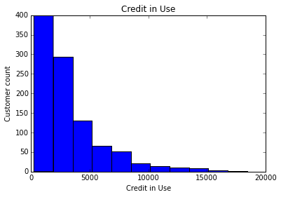

```
#Histogram of Duration
```

```
fig = plt1.pyplot.figure()
```

```
ax = fig.add_subplot(111)
```

```
ax.hist(credit2['duration'], bins = 11, range = (credit2['duration'].min(),credit2['duration'].max()))
```

```
plt1.pyplot.title('Duration')
```

```
plt1.pyplot.xlabel('Duration (in months)')
```

```
plt1.pyplot.ylabel('Customer count')
```

```
plt1.pyplot.show()
```

```
savefig('durationhist.png')
```

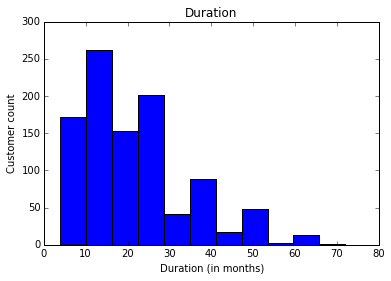

BarPlot

```
# barplot of credit balance grouped by creditability (True or False)
```

```
creditbalance = pd.crosstab(credit2.balance_credit_acc,credit2.creditability).plot(kind='bar')
```

```
plt.title('Credit Balance by Creditability')
```

```
axes.set_xticklabels(a, rotation=45 ,ha='left')
```

```
plt.xlabel('Credit Balance')
```

```
plt.ylabel('Frequency')
```

```
plt.xticks([0,1,2,3],["No Running Account", "No Balance or Debt", "0<=...<200", "...>200 DM"], rotation = 45)
```

```
savefig('creditbalacebar.png')
```

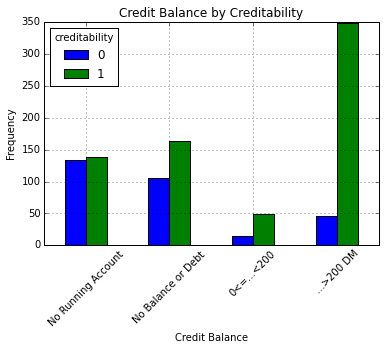

Interesting to note that maximum number of bads are in the categories 1 and 2 which correspond to no running account or Zero Balance respectively

```
#Payment of Previous Credit Vs Creditability
```

```
pd.crosstab(credit2.moral,credit2.creditability).plot(kind='bar')
```

```
plt.title('Payment of Previous Credit by Creditability')
```

```
plt.xlabel('Payment of Previous Credit')
```

```
plt.ylabel('Frequency')
```

```
plt.xticks([0,1,2,3,4],["Hesistant Payment of Previous Credits", "Problematic Running Account/Further Credits at Other Banks", "No/Paid Back Previous Credit", "No Problems with Current Credits at this Bank", "Paid Back Previous Credits at This Bank"], rotation = 45, ha='right')
```

```
savefig('ppcbar.png')
```

```
# It is very interesting to note that number of bads dominate for categories 0 and 1, categories which reflect inconsistencies in payment of previous credits or problematic running account with further credits running at other banks
```

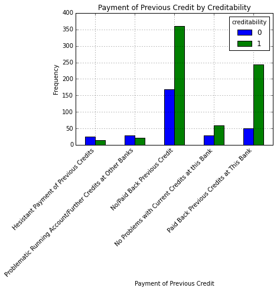

```
#Creditability Vs Status_Gender
```

```
pd.crosstab(credit2.status_sex,credit2.creditability).plot(kind='bar')
```

```
plt.title('Creditability Vs Status_Gender')
```

```
plt.xlabel('Status_Gender')
```

```
plt.ylabel('Frequency')
```

```
plt.xticks([0,1,2,3],["Male: Divorced/Living Apart", "Female: Divorced/Living Apart/Married and Male: Single", "Male: Married/Widowed", "Female: Single"], rotation = 45, ha='right')
```

```
savefig('statusgenderbar.png')
```

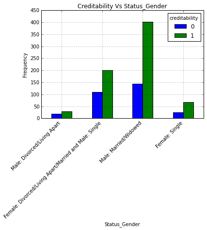

[output not shown]

```
temp3 = pd.crosstab([credit2.balance_credit_acc, credit2.moral], credit2.creditability)
```

```
temp3.plot(kind='bar', stacked=True, color=['red','blue'], grid=False)
```

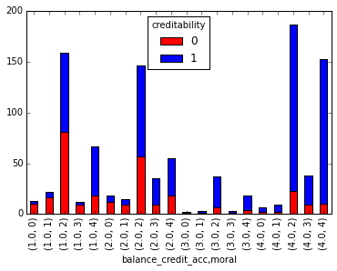

We put together a number of stacked bar charts however none of them proved to be fruitful in terms of giving us insight. The previous chart is just an example of a common result we would get during this course of exploration.

```
#Creditability by Occupation
```

```
pd.crosstab(credit2.occupation, credit2.creditability).plot(kind='bar')
```

```
plt.title('Creditability by Occupation')
```

```
plt.xlabel('Occupation')
```

```
plt.ylabel('Frequency')
```

```
plt.xticks([0,1,2,3],["Unemployed/unskilled with no permanent residence", "Unskilled with permanent residencert", "Skilled worker/skilled employee/minor civil servant", "Executive/self-employed/higher civil servant"], rotation = 45, ha='right')
```

```
savefig('credbyocc.png')
```

```
#Interesting to note that skilled employee/civil servant category also has high number of bad accounts
```

```
#But unemployed/unskilled and executive/self employed have the higher % of bads
```

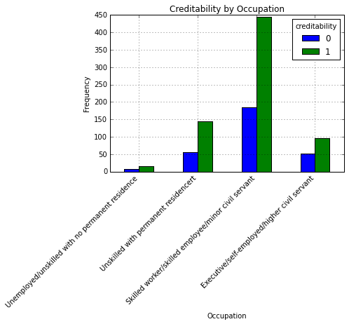

```
#Credit in Use by age Group
```

```
ageGroups = pd.qcut(credit2['age'], 5)
```

```
credit2['ageGroups'] = ageGroups.labels
```

```
cols = ['b', 'r', 'g', 'm', 'y']
```

```
i = 0
```

```
for k, df in credit2.groupby('ageGroups'):
```

```
    plt.scatter(df['age'], df['credit_in_use'], c=cols[i], label=ageGroups.levels[k], alpha=.6)
```

```
    i += 1
```

```
plt.legend()
```

```
plt.xlabel('Age')
```

```
plt.ylabel('Credit in Use');
```

```
savefig('scatterage.png')
```

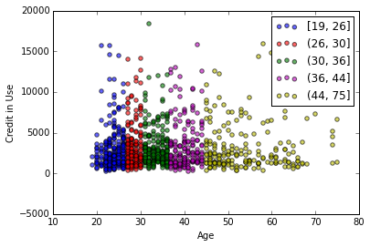

```
#Scatter Plot of Age Vs Credit in Use
```

```
plt.scatter(credit2['credit_in_use'], credit2['age'])
```

```
plt.title('Age Vs Credit in Use')
```

```
plt.xlabel('Credit in Use')
```

```
plt.ylabel('Age')
```

```
savefig('bpagevcredit.png')
```

```
#Maximum credit in use is for the age group 20-40 years, after 40 its starts reducing
```

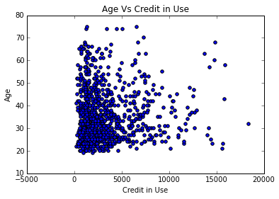

```
#Balance Credit account by Age group
```

```
ageGroups = pd.qcut(credit2['age'], 5)
```

```
credit2['ageGroups'] = ageGroups.labels
```

```
cols = ['b', 'r', 'g', 'm', 'y']
```

```
i = 0
```

```
for k, df in credit2.groupby('ageGroups'):
```

```
    plt.scatter(df['age'], df['balance_credit_acc'], c=cols[i], label=ageGroups.levels[k], alpha=.6)
```

```
    i += 1
```

```
plt.legend()
```

```
plt.xlabel('Age')
```

```
plt.yticks([0,1,2,3],["No Running Account", "No Balance or Debt", "0<=...<200", "...>200 DM"], rotation = 45, ha='right')
```

```
plt.ylabel('Balance Credit Account');
```

```
savefig('scatterlineage.png')
```

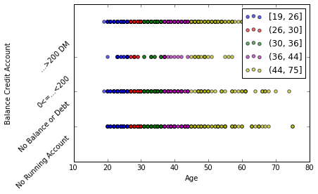

```
#Scatter Plot of Savings or Stocks by Age
```

```
plt.scatter(credit2['savings_or_stocks'], credit2['age'])
```

```
plt.title('Savings or Stocks by Age')
```

```
plt.xlabel('Savings or Stocks')
```

```
plt.ylabel('Age')
```

```
savefig('bpsavorsto.png')
```

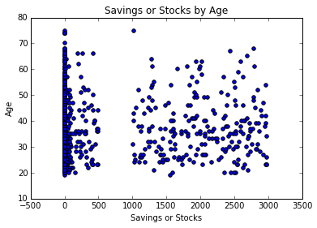

```
#Box Plot for Duration
```

```
credit2.boxplot(column='duration')
```

```
savefig('bpdurationto.png')
```

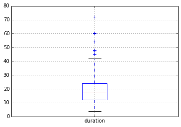

```
#Box Plot for Duration by creditability
```

```
credit2.boxplot(column='duration', by='creditability');
```

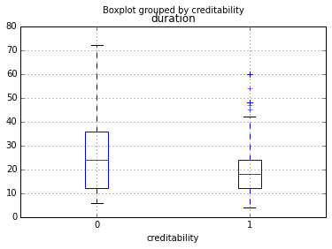

```
#Boxplot for Age
```

```
credit2.boxplot(column='age', by='creditability');
```

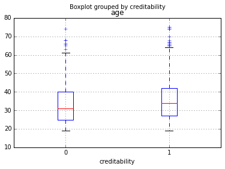

```
#Boxplot for Credit in Use
```

```
credit2.boxplot(column='credit_in_use', by='creditability');
```

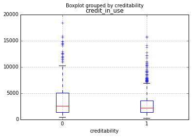

```
#Boxplot for Rate
```

```
credit2.boxplot(column='rate', by='creditability');
```

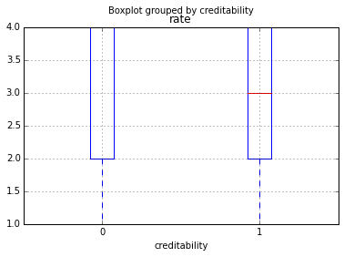

#### TESTS OF COMPARISON

Mann-Whitney-Wilcoxon (MWW) RankSum test.

The MWW RankSum test is a useful test to determine if two distributions are significantly different or not. Unlike the t-test, the RankSum test does not assume that the data are normally distributed, potentially providing a more accurate assessment of the data sets.

```
#Comparison of Age by Creditability i.e. Goods/Bads
```

```
from scipy import stats
```

```
credit_goods = credit2[credit2['creditability'] == 1]['age']
```

```
credit_bads = credit2[credit2['creditability'] == 0]['age']
```

```
z_stat, p_val = stats.ranksums(credit_goods, credit_bads)
```

```
print "P value =", p_val
```

```
#The Average Age of 'Goods' is significantly different from 'Bad'
```

```
P value = 0.000361401995976
```

```
#Comparison of Savings by Creditability i.e. Goods/Bads
```

```
credit_goods_sav = credit2[credit2['creditability'] == 1]['savings_or_stocks']
```

```
credit_bads_sav = credit2[credit2['creditability'] == 0]['savings_or_stocks']
```

```
z_stat, p_val = stats.ranksums(credit_goods_sav, credit_bads_sav)
```

```
print "P value =", p_val
```

```
#The average savings for goods is significantly different from bads
```

```
P value = 1.02096497923e-06
```

```
#Comparison of Credit in use  by Creditability i.e. Goods/Bads
```

```
credit_goods_creduse = credit2[credit2['creditability'] == 1]['credit_in_use']
```

```
credit_bads_creduse = credit2[credit2['creditability'] == 0]['credit_in_use']
```

```
z_stat, p_val = stats.ranksums(credit_goods_creduse, credit_bads_creduse)
```

```
print "P value =", p_val
```

```
#The average credit in use for goods is significantly different from bads
```

```
P value = 0.00711606626898
```

```
#Comparison of economic dependants  by Creditability i.e. for Goods/Bads
```

```
credit_goods_dep = credit2[credit2['creditability'] == 1]['economic_dependants']
```

```
credit_bads_dep = credit2[credit2['creditability'] == 0]['economic_dependants']
```

```
z_stat, p_val = stats.ranksums(credit_goods_dep, credit_bads_dep)
```

```
print "P value =", p_val
```

```
#There is not much difference between goods and bads in terms of number of economic dependants
```

```
P value = 0.962663445113
```

```
#Comparison of economic dependants  by Creditability i.e. for Goods/Bads
```

```
credit_goods_dep = credit2[credit2['creditability'] == 1]['duration']
```

```
credit_bads_dep = credit2[credit2['creditability'] == 0]['duration']
```

```
z_stat, p_val = stats.ranksums(credit_goods_dep, credit_bads_dep)
```

```
print "P value =", p_val
```

[output not shown]

```
P value = 1.48340005706e-10
```

### Model Development

```
#Checking Correlations
```

```
credit2.corr()
```

|  | creditability | balance_credit_acc | duration | moral | credit_purpose | credit_in_use | savings_or_stocks | years_curr_employer | rate | status_sex | ... | curr_hhld_tenure | assets | age | further_credits | apartment_type | prev_credits_here | occupation | economic_dependants | telephone | foreign_worker |
| --- | --- | --- | --- | --- | --- | --- | --- | --- | --- | --- | --- | --- | --- | --- | --- | --- | --- | --- | --- | --- | --- |
| creditability | 1.000000 | 0.349613 | -0.214084 | 0.228311 | -0.018463 | -0.153342 | 0.159141 | 0.118292 | -0.071113 | 0.088984 | ... | 0.001184 | -0.143309 | 0.090773 | 0.110690 | 0.018348 | 0.044718 | -0.032549 | 0.002363 | 0.035260 | 0.081877 |
| balance_credit_acc | 0.349613 | 1.000000 | -0.071142 | 0.191734 | 0.028427 | -0.041382 | 0.162924 | 0.108201 | -0.004131 | 0.043865 | ... | -0.040159 | -0.032716 | 0.058179 | 0.068914 | 0.023525 | 0.075198 | 0.040880 | -0.014696 | 0.065336 | -0.035462 |
| duration | -0.214084 | -0.071142 | 1.000000 | -0.076838 | 0.147769 | 0.624714 | 0.031656 | 0.056437 | 0.074107 | 0.014455 | ... | 0.060829 | 0.304333 | -0.037261 | -0.063257 | 0.153068 | -0.010757 | 0.210861 | -0.023520 | 0.165444 | -0.134573 |
| moral | 0.228311 | 0.191734 | -0.076838 | 1.000000 | -0.090504 | -0.059408 | 0.067290 | 0.139042 | 0.044862 | 0.042407 | ... | 0.056326 | -0.053959 | 0.146166 | 0.160227 | 0.061505 | 0.436875 | 0.010426 | 0.011336 | 0.051980 | 0.028459 |
| credit_purpose | -0.018463 | 0.028427 | 0.147769 | -0.090504 | 1.000000 | 0.068854 | -0.011406 | 0.016433 | 0.048669 | 0.000292 | ... | -0.018539 | 0.010864 | -0.001013 | -0.100106 | 0.013536 | 0.054738 | 0.008130 | -0.032711 | 0.078152 | -0.113310 |
| credit_in_use | -0.153342 | -0.041382 | 0.624714 | -0.059408 | 0.068854 | 1.000000 | 0.065425 | -0.009852 | -0.272603 | -0.016597 | ... | 0.058137 | 0.312179 | 0.032732 | -0.069945 | 0.132956 | 0.021574 | 0.285406 | 0.017624 | 0.278160 | -0.030466 |
| savings_or_stocks | 0.159141 | 0.162924 | 0.031656 | 0.067290 | -0.011406 | 0.065425 | 1.000000 | 0.115118 | 0.011888 | 0.005298 | ... | 0.034329 | 0.010678 | 0.086835 | 0.016937 | -0.008799 | 0.018664 | 0.002146 | 0.019124 | 0.077394 | 0.024932 |
| years_curr_employer | 0.118292 | 0.108201 | 0.056437 | 0.139042 | 0.016433 | -0.009852 | 0.115118 | 1.000000 | 0.125096 | 0.110787 | ... | 0.210452 | 0.087728 | 0.259906 | -0.007904 | 0.115000 | 0.126880 | 0.101120 | 0.097862 | 0.061697 | -0.022603 |
| rate | -0.071113 | -0.004131 | 0.074107 | 0.044862 | 0.048669 | -0.272603 | 0.011888 | 0.125096 | 1.000000 | 0.118957 | ... | 0.030938 | 0.053731 | 0.057668 | 0.007474 | 0.091143 | 0.022332 | 0.097663 | -0.070850 | 0.015181 | -0.094624 |
| status_sex | 0.088984 | 0.043865 | 0.014455 | 0.042407 | 0.000292 | -0.016597 | 0.005298 | 0.110787 | 0.118957 | 1.000000 | ... | -0.056597 | -0.006788 | 0.005331 | -0.026960 | 0.098884 | 0.065012 | -0.012024 | 0.122381 | 0.027657 | 0.073200 |
| debtors_guarantors | 0.024702 | -0.128225 | -0.024269 | -0.040836 | -0.017700 | -0.027517 | -0.092557 | -0.007717 | -0.011124 | 0.050778 | ... | -0.036576 | -0.155570 | -0.029951 | -0.038101 | -0.065412 | -0.025669 | -0.057922 | 0.020272 | -0.075314 | 0.140140 |
| curr_hhld_tenure | 0.001184 | -0.040159 | 0.060829 | 0.056326 | -0.018539 | 0.058137 | 0.034329 | 0.210452 | 0.030938 | -0.056597 | ... | 1.000000 | 0.153667 | 0.255826 | 0.006223 | 0.084092 | 0.083261 | 0.021104 | 0.038110 | 0.089609 | -0.039201 |
| assets | -0.143309 | -0.032716 | 0.304333 | -0.053959 | 0.010864 | 0.312179 | 0.010678 | 0.087728 | 0.053731 | -0.006788 | ... | 0.153667 | 1.000000 | 0.074425 | -0.107454 | 0.343038 | -0.008008 | 0.276219 | 0.011728 | 0.196599 | -0.132539 |
| age | 0.090773 | 0.058179 | -0.037261 | 0.146166 | -0.001013 | 0.032732 | 0.086835 | 0.259906 | 0.057668 | 0.005331 | ... | 0.255826 | 0.074425 | 1.000000 | -0.030293 | 0.303428 | 0.150485 | 0.015443 | 0.118438 | 0.143236 | 0.013904 |
| further_credits | 0.110690 | 0.068914 | -0.063257 | 0.160227 | -0.100106 | -0.069945 | 0.016937 | -0.007904 | 0.007474 | -0.026960 | ... | 0.006223 | -0.107454 | -0.030293 | 1.000000 | -0.097472 | -0.055504 | 0.006010 | -0.076708 | -0.024771 | 0.007791 |
| apartment_type | 0.018348 | 0.023525 | 0.153068 | 0.061505 | 0.013536 | 0.132956 | -0.008799 | 0.115000 | 0.091143 | 0.098884 | ... | 0.084092 | 0.343038 | 0.303428 | -0.097472 | 1.000000 | 0.050129 | 0.104225 | 0.115619 | 0.100474 | -0.083312 |
| prev_credits_here | 0.044718 | 0.075198 | -0.010757 | 0.436875 | 0.054738 | 0.021574 | 0.018664 | 0.126880 | 0.022332 | 0.065012 | ... | 0.083261 | -0.008008 | 0.150485 | -0.055504 | 0.050129 | 1.000000 | -0.026224 | 0.109402 | 0.065010 | -0.019036 |
| occupation | -0.032549 | 0.040880 | 0.210861 | 0.010426 | 0.008130 | 0.285406 | 0.002146 | 0.101120 | 0.097663 | -0.012024 | ... | 0.021104 | 0.276219 | 0.015443 | 0.006010 | 0.104225 | -0.026224 | 1.000000 | -0.093506 | 0.383277 | -0.092809 |
| economic_dependants | 0.002363 | -0.014696 | -0.023520 | 0.011336 | -0.032711 | 0.017624 | 0.019124 | 0.097862 | -0.070850 | 0.122381 | ... | 0.038110 | 0.011728 | 0.118438 | -0.076708 | 0.115619 | 0.109402 | -0.093506 | 1.000000 | -0.015113 | 0.076995 |
| telephone | 0.035260 | 0.065336 | 0.165444 | 0.051980 | 0.078152 | 0.278160 | 0.077394 | 0.061697 | 0.015181 | 0.027657 | ... | 0.089609 | 0.196599 | 0.143236 | -0.024771 | 0.100474 | 0.065010 | 0.383277 | -0.015113 | 1.000000 | -0.075201 |
| foreign_worker | 0.081877 | -0.035462 | -0.134573 | 0.028459 | -0.113310 | -0.030466 | 0.024932 | -0.022603 | -0.094624 | 0.073200 | ... | -0.039201 | -0.132539 | 0.013904 | 0.007791 | -0.083312 | -0.019036 | -0.092809 | 0.076995 | -0.075201 | 1.000000 |

21 rows × 21 columns

We want to add an intercept column as well as create some dummy variables for categorical variables. The dmatrices function from the patsy module can do that using formula language.

```
import statsmodels.api as sm
```

```
from patsy import dmatrices
```

```
from sklearn.linear_model import LogisticRegression
```

```
from sklearn.cross_validation import train_test_split
```

```
from sklearn import metrics
```

```
from sklearn.cross_validation import cross_val_score
```

```
y, X = dmatrices('creditability ~ duration + credit_in_use + savings_or_stocks + age + curr_hhld_tenure + C(balance_credit_acc) +C(moral) + C(credit_purpose) + C(years_curr_employer) + C(rate) + C(status_sex) + C(debtors_guarantors) + \
```

```
                  C(assets) + C(further_credits) + C(apartment_type) + prev_credits_here + C(occupation) + economic_dependants + C(telephone) + C(foreign_worker)',credit2, return_type="dataframe")
```

```
print X.columns
```

```
Index([u'Intercept', u'C(balance_credit_acc)[T.2.0]', u'C(balance_credit_acc)[T.3.0]', u'C(balance_credit_acc)[T.4.0]', u'C(moral)[T.1]', u'C(moral)[T.2]', u'C(moral)[T.3]', u'C(moral)[T.4]', u'C(credit_purpose)[T.1]', u'C(credit_purpose)[T.2]', u'C(credit_purpose)[T.3]', u'C(credit_purpose)[T.4]', …
```

```
# flatten y into a 1-D array
```

```
y = np.ravel(y)
```

```
# instantiate a logistic regression model, and fit with X and y
```

```
model = LogisticRegression()
```

```
model = model.fit(X, y)
```

```
# check the accuracy on the training set
```

```
model.score(X, y)
```

```
0.78678678678678682
```

[output not shown]

```
credit3=credit2.drop(['age'], axis=1)
```

#### Getting Paramater Estimate Table for understanding Significant Variables in the Model

```
# We are using Logit Function from StatsModels to build the Model.
```

```
#Creditability is the dependent Variable in the below code chunk.
```

```
train_cols = credit2.columns[1:]
```

```
logit = sm.Logit(credit2['creditability'], credit2[train_cols])
```

```
# fit the model
```

```
result = logit.fit()
```

```
print result.summary()
```

```
Optimization terminated successfully.
         Current function value: 0.486873
         Iterations 6
                           Logit Regression Results
==============================================================================
Dep. Variable:          creditability   No. Observations:                  999
Model:                          Logit   Df Residuals:                      979
Method:                           MLE   Df Model:                           19
Date:                Sun, 30 Nov 2014   Pseudo R-squ.:                  0.2022
Time:                        20:52:53   Log-Likelihood:                -486.39
converged:                       True   LL-Null:                       -609.66
                                        LLR p-value:                 1.547e-41
=======================================================================================
                          coef    std err          z      P>|z|      [95.0% Conf. Int.]
---------------------------------------------------------------------------------------
balance_credit_acc      0.5633      0.068      8.275      0.000         0.430     0.697
duration               -0.0270      0.009     -3.116      0.002        -0.044    -0.010
moral                   0.3721      0.087      4.299      0.000         0.202     0.542
credit_purpose          0.0155      0.029      0.526      0.599        -0.042     0.073
credit_in_use       -7.867e-05   4.03e-05     -1.952      0.051        -0.000  3.21e-07
savings_or_stocks       0.0004      0.000      3.656      0.000         0.000     0.001
years_curr_employer     0.1319      0.070      1.886      0.059        -0.005     0.269
rate                   -0.3362      0.082     -4.094      0.000        -0.497    -0.175
status_sex              0.1804      0.114      1.589      0.112        -0.042     0.403
debtors_guarantors      0.1935      0.167      1.159      0.246        -0.134     0.521
curr_hhld_tenure        0.0050      0.010      0.519      0.604        -0.014     0.024
assets                 -0.2304      0.089     -2.586      0.010        -0.405    -0.056
age                     0.0051      0.008      0.632      0.527        -0.011     0.021
further_credits         0.0580      0.101      0.571      0.568        -0.141     0.257
apartment_type          0.1871      0.162      1.152      0.249        -0.131     0.505
prev_credits_here      -0.3545      0.157     -2.255      0.024        -0.663    -0.046
occupation             -0.1215      0.131     -0.931      0.352        -0.377     0.134
economic_dependants    -0.3563      0.221     -1.615      0.106        -0.789     0.076
telephone               0.2281      0.185      1.230      0.219        -0.135     0.591
foreign_worker         -0.0815      0.388     -0.210      0.834        -0.842     0.679
=======================================================================================
```

The variables that were found significant in the Model (at 95% Confidence Level)and that increase or decrease the likelihood of a customer being classified as 'GOOD' were as follows:

Balance Credit Account-> Higher balance increases the likelihood of customer being classified as'Good'

Duration of Credit-> Longer a customer takes to pay back-decrease the likelihood of customer being classified as 'Good'

Moral-Payment of Previous Credits-> If a customer has regularly cleared his past credits-it increase his likelihood of being classified as 'Good'

Savings or Stocks-> More savings increase the likelihood of customer being classified as 'Good'

Rate-> (Ratio of Installment to Income)-> Higher Rate, decreases the likelihood of customer being classified as 'Good'

Assets-> More the number of assets, lesser the likelihood of being 'Good'

Number of Previous Credits at the Bank-> Higher the number of previous credits at the Bank, lesser the likelihood of being 'Good'.

[output not shown]

```
#Getting Paramater Estimate Table for understanding Significant Variables in the Model (Model with ageGroups)
```

```
train_cols = credit3.columns[1:]
```

```
logit = sm.Logit(credit3['creditability'], credit3[train_cols])
```

```
# fit the model
```

```
result = logit.fit()
```

```
print result.summary()
```

```
Optimization terminated successfully.
         Current function value: 0.487074
         Iterations 6
                           Logit Regression Results
==============================================================================
Dep. Variable:          creditability   No. Observations:                  999
Model:                          Logit   Df Residuals:                      980
Method:                           MLE   Df Model:                           18
Date:                Sun, 30 Nov 2014   Pseudo R-squ.:                  0.2019
Time:                        20:53:03   Log-Likelihood:                -486.59
converged:                       True   LL-Null:                       -609.66
                                        LLR p-value:                 4.956e-42
=======================================================================================
                          coef    std err          z      P>|z|      [95.0% Conf. Int.]
---------------------------------------------------------------------------------------
balance_credit_acc      0.5631      0.068      8.279      0.000         0.430     0.696
duration               -0.0276      0.009     -3.202      0.001        -0.044    -0.011
moral                   0.3744      0.086      4.331      0.000         0.205     0.544
credit_purpose          0.0156      0.029      0.530      0.596        -0.042     0.073
credit_in_use       -7.741e-05   4.03e-05     -1.921      0.055        -0.000  1.56e-06
savings_or_stocks       0.0004      0.000      3.682      0.000         0.000     0.001
years_curr_employer     0.1400      0.069      2.041      0.041         0.006     0.274
rate                   -0.3325      0.082     -4.058      0.000        -0.493    -0.172
status_sex              0.1767      0.113      1.558      0.119        -0.046     0.399
debtors_guarantors      0.1973      0.167      1.181      0.238        -0.130     0.525
curr_hhld_tenure        0.0059      0.009      0.624      0.533        -0.013     0.025
assets                 -0.2308      0.089     -2.592      0.010        -0.405    -0.056
further_credits         0.0586      0.101      0.578      0.563        -0.140     0.257
apartment_type          0.2188      0.155      1.415      0.157        -0.084     0.522
prev_credits_here      -0.3458      0.156     -2.213      0.027        -0.652    -0.040
occupation             -0.1219      0.130     -0.936      0.349        -0.377     0.133
economic_dependants    -0.3408      0.219     -1.556      0.120        -0.770     0.089
telephone               0.2434      0.184      1.324      0.185        -0.117     0.604
foreign_worker         -0.0563      0.386     -0.146      0.884        -0.814     0.701
=======================================================================================
```

```
# examine the coefficients
```

```
pd.DataFrame(zip(X.columns, np.transpose(model.coef_)))
```

|  | 0 | 1 |
| --- | --- | --- |
| 0 | Intercept | [-0.0121877135714] |
| 1 | C(balance_credit_acc)[T.2.0] | [0.37762672508] |
| 2 | C(balance_credit_acc)[T.3.0] | [0.791697003098] |
| 3 | C(balance_credit_acc)[T.4.0] | [1.64224516872] |
| 4 | C(moral)[T.1] | [-0.318610376871] |
| 5 | C(moral)[T.2] | [0.281737147801] |
| 6 | C(moral)[T.3] | [0.48941471575] |
| 7 | C(moral)[T.4] | [1.03852607806] |
| 8 | C(credit_purpose)[T.1] | [1.27594779943] |
| 9 | C(credit_purpose)[T.2] | [0.539976572316] |
| 10 | C(credit_purpose)[T.3] | [0.689435027514] |
| 11 | C(credit_purpose)[T.4] | [0.175159908727] |
| 12 | C(credit_purpose)[T.5] | [0.030634097622] |
| 13 | C(credit_purpose)[T.6] | [-0.165501983542] |
| 14 | C(credit_purpose)[T.8] | [0.696476572279] |
| 15 | C(credit_purpose)[T.9] | [0.430592680243] |
| 16 | C(credit_purpose)[T.10] | [0.745510120284] |
| 17 | C(years_curr_employer)[T.2] | [-0.151672121083] |
| 18 | C(years_curr_employer)[T.3] | [-0.0269663369975] |
| 19 | C(years_curr_employer)[T.4] | [0.597102729313] |
| 20 | C(years_curr_employer)[T.5] | [0.0647482113535] |
| 21 | C(rate)[T.2] | [-0.18770410465] |
| 22 | C(rate)[T.3] | [-0.506395911718] |
| 23 | C(rate)[T.4] | [-0.794255553193] |
| 24 | C(status_sex)[T.2] | [0.0849579210002] |
| 25 | C(status_sex)[T.3] | [0.597490972843] |
| 26 | C(status_sex)[T.4] | [0.243067159039] |
| 27 | C(debtors_guarantors)[T.2] | [-0.321519952674] |
| 28 | C(debtors_guarantors)[T.3] | [0.73167895297] |
| 29 | C(assets)[T.2] | [-0.238883938071] |
| 30 | C(assets)[T.3] | [-0.200547126282] |
| 31 | C(assets)[T.4] | [-0.562810824378] |
| 32 | C(further_credits)[T.2] | [-0.00832404163197] |
| 33 | C(further_credits)[T.3] | [0.36464070212] |
| 34 | C(apartment_type)[T.2] | [0.438685197171] |
| 35 | C(apartment_type)[T.3] | [0.399062732104] |
| 36 | C(occupation)[T.2] | [-0.191613171713] |
| 37 | C(occupation)[T.3] | [-0.209477845213] |
| 38 | C(occupation)[T.4] | [-0.17454882097] |
| 39 | C(telephone)[T.2] | [0.260005846786] |
| 40 | C(foreign_worker)[T.2] | [0.958033672445] |
| 41 | duration | [-0.028059663449] |
| 42 | credit_in_use | [-0.000112497968622] |
| 43 | savings_or_stocks | [0.000421076143159] |
| 44 | age | [0.0116645198458] |
| 45 | curr_hhld_tenure | [0.00831506094045] |
| 46 | prev_credits_here | [-0.287941897542] |
| 47 | economic_dependants | [-0.222589259033] |

Odds ratio: Take the exponential of each of the coeffecients to generate the odds ratios. This tells you how a 1 unit increase or decrease in a variable affects the odds of being good or bad

```
print np.exp(result.params)
```

[output not shown]

### Model Evaluation Using a Validation Set

Split the data into a training set and a testing set.

```
#Evaluate the model by splitting into train and test sets
```

```
X_train, X_test, y_train, y_test = train_test_split(X, y, test_size=0.3, random_state=0)
```

```
model2 = LogisticRegression()
```

```
model2.fit(X_train, y_train)
```

```
LogisticRegression(C=1.0, class_weight=None, dual=False, fit_intercept=True,
          intercept_scaling=1, penalty='l2', random_state=None, tol=0.0001)
```

We now need to predict class labels for the test set. We will also generate the class probabilities, just to take a look

```
# predict class labels for the test set
```

```
predicted = model2.predict(X_test)
```

```
print predicted
```

```
[ 1.  1.  0.  0.  1.  1.  1.  1.  1.  1.  1.  1.  1.  1.  0.  1.  1.  1.
  0.  1.  1.  1.  1.  1.  0.  1.  1.  1.  1.  1.  1.  1.  1.  1.  1.  1.
  1.  1.  1.  1.  1.  1.  1.  0.  1.  0.  1.  1.  1.  0.  1.  0.  1.  1.
  1.  1.  1.  1.  1.  1.  1.  1.  1.  0.  0.  1.  1.  1.  1.  1.  1.  1.
  1.  1.  0.  1.  1.  1.  1.  1.  1.  1.  0.  1.  1.  1.  1.  0.  1.  1.
  1.  1.  1.  1.  1.  1.  0.  1.  1.  1.  1.  1.  1.  1.  1.  1.  1.  1.
  1.  1.  1.  1.  0.  1.  1.  0.  1.  0.  1.  1.  1.  0.  1.  1.  1.  1.
  1.  1.  0.  1.  1.  0.  1.  1.  1.  1.  1.  0.  1.  1.  1.  1.  1.  1.
  1.  1.  1.  1.  1.  0.  0.  1.  0.  1.  1.  1.  1.  1.  0.  1.  1.  1.
  1.  1.  0.  1.  1.  1.  1.  1.  1.  0.  1.  1.  1.  1.  1.  1.  1.  1.
  1.  1.  1.  1.  1.  1.  0.  1.  1.  1.  1.  1.  1.  1.  1.  1.  1.  1.
  1.  1.  0.  1.  0.  0.  0.  1.  1.  1.  1.  0.  1.  1.  0.  1.  1.  1.
  1.  1.  1.  1.  1.  1.  1.  1.  1.  1.  1.  0.  1.  1.  1.  1.  1.  1.
  1.  0.  1.  0.  1.  1.  1.  1.  1.  1.  1.  0.  1.  1.  1.  1.  1.  1.
  1.  1.  1.  1.  1.  0.  0.  1.  1.  1.  1.  0.  1.  0.  1.  1.  1.  1.
  1.  0.  0.  1.  1.  1.  1.  1.  1.  1.  0.  1.  1.  1.  1.  0.  1.  1.
  1.  1.  0.  1.  1.  1.  1.  1.  0.  1.  1.  1.]
```

```
# generate class probabilities
```

```
probs = model2.predict_proba(X_test)
```

```
print probs
```

```
[[ 0.06007539  0.93992461]
 [ 0.03019889  0.96980111]
 [ 0.74700559  0.25299441]
 [ 0.60789523  0.39210477]
 [ 0.40164885  0.59835115]
 [ 0.00981404  0.99018596]
 [ 0.24139895  0.75860105]
 [ 0.38900518  0.61099482]
 [ 0.09268453  0.90731547]
 [ 0.30392126  0.69607874]
 [ 0.26736449  0.73263551]
 [ 0.20500362  0.79499638]
 [ 0.01003956  0.98996044]
 [ 0.38628991  0.61371009]
 [ 0.55373606  0.44626394]
 [ 0.08341844  0.91658156]
 [ 0.1627444   0.8372556 ]
 [ 0.29400282  0.70599718]
 [ 0.67024676  0.32975324]
 [ 0.24057249  0.75942751]
 [ 0.49037669  0.50962331]
 [ 0.24049486  0.75950514]
 [ 0.08795595  0.91204405]
 [ 0.47104693  0.52895307]
 [ 0.72950539  0.27049461]
 [ 0.12661242  0.87338758]
 [ 0.1824871   0.8175129 ]
 [ 0.18953348  0.81046652]
 [ 0.0224501   0.9775499 ]
 [ 0.24705504  0.75294496]
 [ 0.48194466  0.51805534]
 [ 0.17618143  0.82381857]
 [ 0.0901367   0.9098633 ]
 [ 0.18583059  0.81416941]
 [ 0.19385775  0.80614225]
 [ 0.30740818  0.69259182]
 [ 0.10446397  0.89553603]
 [ 0.45208808  0.54791192]
 [ 0.48633891  0.51366109]
 [ 0.3431594   0.6568406 ]
```

[output cut: 245 more lines]

```
 [ 0.60161769  0.39838231]
 [ 0.01948707  0.98051293]
 [ 0.39847267  0.60152733]
 [ 0.03587168  0.96412832]
 [ 0.13205336  0.86794664]
 [ 0.63052841  0.36947159]
 [ 0.33392691  0.66607309]
 [ 0.03910395  0.96089605]
 [ 0.05663108  0.94336892]
 [ 0.25657578  0.74342422]
 [ 0.20486229  0.79513771]
 [ 0.52973934  0.47026066]
 [ 0.08923605  0.91076395]
 [ 0.1992195   0.8007805 ]
 [ 0.38830194  0.61169806]]
```

```
#As you can see, the classifier is predicting a 1 (Good Account) any time the probability in the second column is greater than 0.5.
```

```
#In next step we need to generate some evaluation metrics.
```

```
# generate evaluation metrics
```

```
print metrics.accuracy_score(y_test, predicted)
```

```
print metrics.roc_auc_score(y_test, predicted)
```

```
0.76
0.65435561789
```

### Model evaluation using cross-validation: 10-fold cross-validation, to see if the accuracy holds up more rigorously.

```
# evaluate the model using 10-fold cross-validation
```

```
scores = cross_val_score(LogisticRegression(), X, y, scoring='accuracy', cv=10)
```

```
print scores
```

```
print scores.mean()
```

```
[ 0.75        0.76        0.77        0.71        0.74        0.75        0.75
  0.79        0.69        0.81818182]
0.752818181818
```

The Model Performance is quite good. It's still performing at 70%+ accuracy and therefore can be recommended to solve this case.